# Explore and compare structured and unstructured data for the Western Cape at pentad resolution

Katelyn Faulkner

2025-04-13

```r
# Load packages
library(tidyverse) # Data wrangling and visualisation
library(here)      # Relative paths
library(sf)        # Work with spatial data
library(ggpubr)    # Correlations
library(DT)        # Data tables for html
library(RColorBrewer)   # Colour palette
library(vcd)       # Kappa statistics
library(vegan)     # Bray kurtis index
```

# Goal

Explore structured data of the Western Cape, South Africa from the “Southern African Bird Atlas Project 2” (SABAP2).

Explore unstructured data from GBIF for the same area.

Structured and unstructured data were prepared at both quarter degree grid cell (QDGC) and pentad (5 min x 5 min) scales, but only pentad scale data is explored and analysed below.

In these analysis various subsets of the data were explored 1. All species in SABAP2 2. All species with > 100 records in SABAP2 3. Number of observations per species/total number of observations

Data for two time periods explored 2015-2024 and 2015-2022

```r
# Create a custom color scale
library(RColorBrewer)
myColors <- brewer.pal(5, "Dark2")
names(myColors) <- c("Very rare", "Rare", "Common",
                     "Very common", "Extremely common")
colScale <- scale_color_manual(name = "Category",
                                values = myColors)
fillScale <- scale_fill_manual(name = "Category",
                                values = myColors)
```

# Load data

## Structured data

### Sampling framework

The sampling framework was prepared and stored as a geopackage file in *./data/interim*.

We read in the dataset.

```r
# Data path
data_path <- here::here("data", "interim")
```

```r
# Read SABAP2 Western Cape sampling framework (5min x 5 min/ 8.2 km x 8.2 km)
WCSF <- read_sf(file.path(data_path, "sampling_framework_SABAP2_pentad_WC.gpkg"))

# Explore dataframe
glimpse(WCSF)
```

```
## Rows: 1,842
## Columns: 22
## $ pentad       <chr> "3025_1830", "3030_1830", "3030_1835", "3035_1825", "3035…
## $ `2008`       <dbl> 0, 0, 0, 0, 0, 0, 0, 0, 0, 0, 0, 0, 0, 0, 0, 0, 0, 0, 0, …
## $ `2009`       <dbl> 0, 0, 0, 0, 0, 0, 0, 0, 0, 0, 0, 0, 0, 0, 0, 0, 0, 0, 0, …
## $ `2010`       <dbl> 0, 0, 0, 0, 1, 0, 1, 0, 0, 0, 0, 0, 0, 0, 0, 0, 0, 0, 0, …
## $ `2011`       <dbl> 0, 1, 1, 1, 0, 1, 1, 0, 2, 0, 1, 1, 1, 1, 1, 1, 0, 1, 1, …
## $ `2012`       <dbl> 0, 0, 0, 0, 1, 2, 1, 1, 1, 0, 0, 0, 0, 0, 0, 1, 1, 0, 1, …
## $ `2013`       <dbl> 2, 1, 1, 1, 0, 2, 2, 0, 1, 0, 0, 0, 0, 0, 0, 0, 0, 0, 0, …
## $ `2014`       <dbl> 0, 0, 0, 0, 0, 0, 1, 0, 0, 0, 0, 0, 0, 0, 0, 0, 0, 0, 0, …
## $ `2015`       <dbl> 0, 0, 0, 0, 0, 1, 2, 0, 0, 0, 0, 0, 0, 0, 0, 0, 0, 0, 0, …
## $ `2016`       <dbl> 0, 1, 0, 0, 0, 0, 1, 1, 0, 2, 3, 1, 0, 0, 1, 0, 0, 0, 0, …
## $ `2017`       <dbl> 0, 0, 0, 0, 0, 0, 0, 0, 0, 0, 0, 1, 1, 0, 0, 0, 0, 1, 0, …
## $ `2018`       <dbl> 0, 0, 0, 0, 0, 0, 0, 0, 0, 0, 0, 1, 0, 0, 0, 0, 0, 0, 0, …
## $ `2019`       <dbl> 0, 0, 0, 0, 0, 0, 2, 0, 0, 0, 0, 0, 0, 0, 0, 0, 0, 0, 0, …
## $ `2020`       <dbl> 0, 0, 0, 0, 0, 0, 2, 0, 0, 0, 0, 0, 0, 2, 0, 0, 0, 0, 0, …
## $ `2021`       <dbl> 0, 0, 0, 0, 0, 0, 2, 0, 0, 0, 0, 0, 0, 0, 0, 0, 0, 0, 0, …
## $ `2022`       <dbl> 0, 0, 0, 0, 0, 0, 3, 0, 0, 0, 0, 1, 0, 0, 0, 0, 0, 0, 0, …
## $ `2023`       <dbl> 0, 0, 0, 0, 1, 1, 2, 0, 0, 0, 0, 0, 0, 0, 0, 0, 0, 2, 0, …
## $ `2024`       <dbl> 0, 0, 0, 0, 0, 0, 0, 0, 0, 0, 0, 0, 0, 5, 0, 1, 0, 0, 0, …
## $ format       <chr> "geoJSON", "geoJSON", "geoJSON", "geoJSON", "geoJSON", "g…
## $ fullprotocol <dbl> 2, 3, 2, 2, 3, 7, 20, 2, 4, 2, 4, 5, 2, 8, 2, 3, 1, 4, 2,…
## $ qdgccode     <chr> "E018S30BC", "E018S30DA", "E018S30DA", "E018S30CB", "E018…
## $ geom         <POLYGON [°]> POLYGON ((18.5 -30.41667, 1..., POLYGON ((18.5 -3…
```

### Occurrence data

The SABAP2 data were prepared and stored as a geopackage file in *./data/interim*.

We read in the dataset.

```r
# Read SABAP2 Western Cape bird data (5min x 5 min/ 8.2 km x 8.2 km)
SABAP2WCinterim <- read_sf(file.path(data_path, "SABAP2_Pentad_WC_data.gpkg"))

# Explore dataframe
glimpse(SABAP2WCinterim)
```

```
## Rows: 2,146,731
## Columns: 246
## $ pentad                              <chr> "3025_1830", "3025_1830", "3025_18…
## $ `2008`                              <dbl> 0, 0, 0, 0, 0, 0, 0, 0, 0, 0, 0, 0…
## $ `2009`                              <dbl> 0, 0, 0, 0, 0, 0, 0, 0, 0, 0, 0, 0…
## $ `2010`                              <dbl> 0, 0, 0, 0, 0, 0, 0, 0, 0, 0, 0, 0…
## $ `2011`                              <dbl> 0, 0, 0, 0, 0, 0, 0, 0, 0, 0, 0, 0…
## $ `2012`                              <dbl> 0, 0, 0, 0, 0, 0, 0, 0, 0, 0, 0, 0…
## $ `2013`                              <dbl> 2, 2, 2, 2, 2, 2, 2, 2, 2, 2, 2, 2…
## $ `2014`                              <dbl> 0, 0, 0, 0, 0, 0, 0, 0, 0, 0, 0, 0…
## $ `2015`                              <dbl> 0, 0, 0, 0, 0, 0, 0, 0, 0, 0, 0, 0…
## $ `2016`                              <dbl> 0, 0, 0, 0, 0, 0, 0, 0, 0, 0, 0, 0…
## $ `2017`                              <dbl> 0, 0, 0, 0, 0, 0, 0, 0, 0, 0, 0, 0…
## $ `2018`                              <dbl> 0, 0, 0, 0, 0, 0, 0, 0, 0, 0, 0, 0…
## $ `2019`                              <dbl> 0, 0, 0, 0, 0, 0, 0, 0, 0, 0, 0, 0…
```

[output cut: 233 more lines]

## Unstructured data cube

Unstructured data from GBIF were prepared and stored as a geopackage file in *./data/interim*.

We read in the dataset.

```r
# Read in unstructured Western Cape bird data (5min x 5 min/ 8.2 km x 8.2 km)
UnstrucWCinterim <- read_sf(file.path(data_path, "birdcube_Pentad_year_WC.gpkg"))

# Explore dataframe
glimpse(UnstrucWCinterim)
```

```
## Rows: 280,854
## Columns: 29
## $ pentad                           <chr> "3035_1840", "3035_1840", "3035_1840"…
## $ `2008`                           <dbl> 0, 0, 0, 0, 0, 0, 0, 0, 0, 0, 0, 0, 0…
## $ `2009`                           <dbl> 0, 0, 0, 0, 0, 0, 0, 0, 0, 0, 0, 0, 0…
## $ `2010`                           <dbl> 1, 1, 1, 1, 1, 1, 1, 1, 1, 1, 1, 1, 1…
## $ `2011`                           <dbl> 1, 1, 1, 1, 1, 1, 1, 1, 1, 1, 1, 1, 1…
## $ `2012`                           <dbl> 1, 1, 1, 1, 1, 1, 1, 1, 1, 1, 1, 1, 1…
## $ `2013`                           <dbl> 2, 2, 2, 2, 2, 2, 2, 2, 2, 2, 2, 2, 2…
## $ `2014`                           <dbl> 1, 1, 1, 1, 1, 1, 1, 1, 1, 1, 1, 1, 1…
## $ `2015`                           <dbl> 2, 2, 2, 2, 2, 2, 2, 2, 2, 2, 2, 2, 2…
## $ `2016`                           <dbl> 1, 1, 1, 1, 1, 1, 1, 1, 1, 1, 1, 1, 1…
## $ `2017`                           <dbl> 0, 0, 0, 0, 0, 0, 0, 0, 0, 0, 0, 0, 0…
## $ `2018`                           <dbl> 0, 0, 0, 0, 0, 0, 0, 0, 0, 0, 0, 0, 0…
## $ `2019`                           <dbl> 2, 2, 2, 2, 2, 2, 2, 2, 2, 2, 2, 2, 2…
```

[output cut: 16 more lines]

# Explore SABAP2 data

The Western Cape is a South African province that is 129 462 km². As in the rest of South Africa bird surveys following the Southern African Bird Atlas Programme 2 (SABAP2) standard protocol have been conducted since 2007. The data are collected following a standardised protocol (i.e., BirdMap protocol), whereby at least two hours, but a maximum of five days, are spent recording as many different bird species in the grid cell as possible, with the end of each hour of the survey noted. The data are available at a 5-minute<sup>2</sup> spatial resolution, which equates to a resolution of ~ 8.2 km<sup>2</sup> in southern Africa. The area covers 1842 grid cells. The surveys are not systematically repeated over time (except in the Hessequa Atlas Area), but some grid cells have been surveyed more than once. Details on the surveys (how many, when and where) are available. The surveys are performed by citizens, but data go through quality control.

Data between 2008 and 2024 have been prepared.

In the bird record data, it was noted that there were 50316 records where ’species; was NA. Further investigation (examination of scientificName) indicated that these records were not identified to species level and were for:

- “Zosterope”: a synonym according to GBIF of Zosterops Vigors & Horsfield, 1827
- “Psalidoprocne Cabanis, 1850”
- “Buteo Lacepede, 1799”
- “Sylvia Scopoli, 1769”
- “Anas Linnaeus, 1758”
- “Aves”

These records were removed for the analysis. But note there are species missing in this dataset that fall under these genera (see below).

## Survey data

```r
# Drop geometry, convert to long format, convert year into three-year cycles
WCSFprep <-WCSF %>% st_drop_geometry() %>%
pivot_longer(
  cols = '2008':'2024',
  names_to = c("year"),
  values_to = "count"
) %>%
  mutate(year = as.numeric(year)) %>%
  mutate(cyclus = case_when(
    year == 2008 | year == 2009 | year == 2010 ~ 1,
    year == 2011 | year == 2012 | year == 2013 ~ 2,
    year == 2014 | year == 2015 | year == 2016 ~ 3,
    year == 2017 | year == 2018 | year == 2019 ~ 4,
    year == 2020 | year == 2021 | year == 2022 ~ 5,
    year == 2023 | year == 2024 ~ 6,
    ))
```

Summary of data:

```r
# summary
summary(WCSFprep[, c("year",
                          "count")])
```

```
##       year          count
##  Min.   :2008   Min.   :  0.000
##  1st Qu.:2012   1st Qu.:  0.000
##  Median :2016   Median :  0.000
##  Mean   :2016   Mean   :  1.996
##  3rd Qu.:2020   3rd Qu.:  1.000
##  Max.   :2024   Max.   :262.000
```

Data collected between 2008 and 2024. Mean of ~2 surveys per year per pentad

```r
# total number of surveys
sum(WCSFprep$count)
```

```
## [1] 62516
```

Total of 62516 surveys

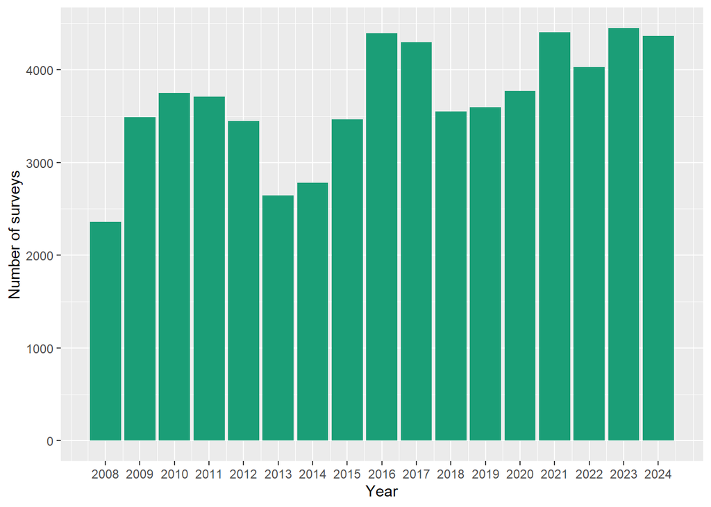

```r
# Number of surveys per year
WCSFprep %>%
  group_by(year) %>%
    summarise(n = sum(count)) %>%
  ggplot(aes(x = year, y = n)) +
  geom_col(fill = "#1B9E77") +
  labs(x = "Year",
       y = "Number of surveys")+ scale_x_continuous(breaks=seq(2008,2024,1))
```

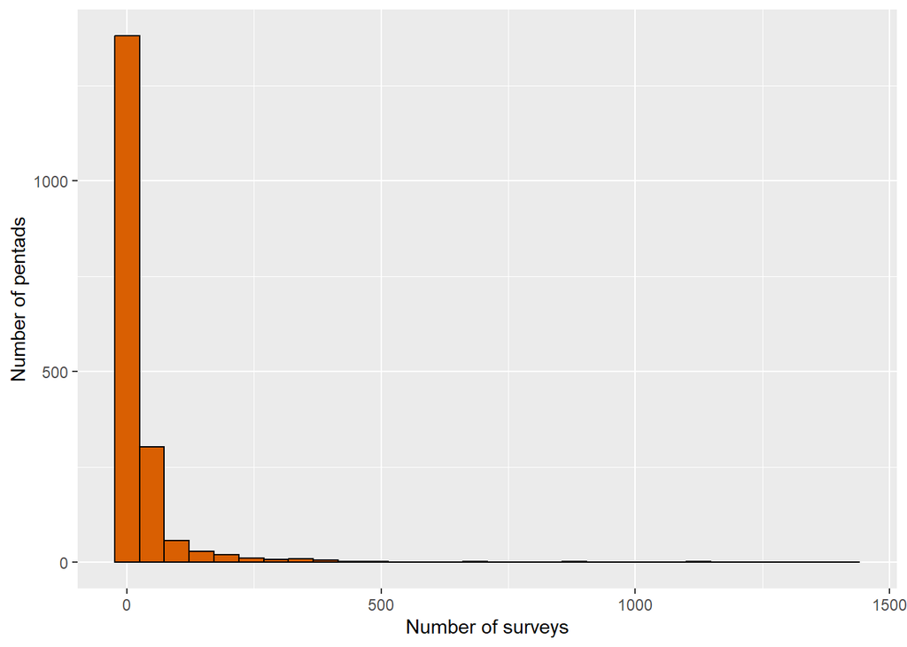

```r
# Number of surveys per pentad
WCSFprep %>%
  group_by(pentad) %>%
    summarise(n = sum(count)) %>%
  ggplot(aes(x = n)) +
  geom_histogram(fill = "#D95F02", color = "black") +
  labs(x = "Number of surveys",
       y = "Number of pentads")
```

Number of surveys varies across the pentads, a few with > 500 surveys, most at < 30 surveys.

## Bird data

```r
# Drop geometry, removed records not identified to species level, classify commonness, and group years. Used three year internals
SABAP2WC <-SABAP2WCinterim %>% st_drop_geometry() %>%
filter(!is.na(species)) %>%
  mutate(cyclus = case_when(
    year == 2008 | year == 2009 | year == 2010 ~ 1,
    year == 2011 | year == 2012 | year == 2013 ~ 2,
    year == 2014 | year == 2015 | year == 2016 ~ 3,
    year == 2017 | year == 2018 | year == 2019 ~ 4,
    year == 2020 | year == 2021 | year == 2022 ~ 5,
    year == 2023 | year == 2024 ~ 6,
    )) %>%
group_by(species) %>%
  mutate(n_obs = n()) %>%
  ungroup() %>%
  mutate(category = cut(n_obs,
                        breaks = c(0, 10, 100, 1000, 10000, +Inf),
                        labels = c("Very rare", "Rare", "Common",
                                   "Very common", "Extremely common"),
                        right = FALSE))

# Group by species, year and pentad
SABAP2WCGrp <-SABAP2WC %>%
   group_by(species, year, pentad, category) %>%
    summarise(n = n())
glimpse(SABAP2WCGrp)
```

```
## Rows: 640,686
## Columns: 5
## Groups: species, year, pentad [640,686]
## $ species  <chr> "Accipiter melanoleucus", "Accipiter melanoleucus", "Accipite…
## $ year     <dbl> 2008, 2008, 2008, 2008, 2008, 2008, 2008, 2008, 2008, 2008, 2…
## $ pentad   <chr> "3235_1900", "3240_1840", "3255_1930", "3305_1835", "3320_182…
## $ category <fct> Very common, Very common, Very common, Very common, Very comm…
## $ n        <int> 1, 1, 2, 1, 1, 1, 1, 1, 1, 1, 4, 2, 5, 1, 1, 1, 2, 3, 2, 1, 1…
```

```r
summary(SABAP2WC [c("eventDate",
                          "year",
                          "month")])
```

```
##    eventDate               year          month
##  Min.   :2008-01-01   Min.   :2008   Min.   : 1.000
##  1st Qu.:2011-11-13   1st Qu.:2011   1st Qu.: 4.000
##  Median :2016-01-07   Median :2016   Median : 7.000
##  Mean   :2015-10-15   Mean   :2015   Mean   : 6.829
##  3rd Qu.:2019-08-07   3rd Qu.:2019   3rd Qu.:10.000
##  Max.   :2023-02-12   Max.   :2023   Max.   :12.000
```

Data run from January 2008 to February 2023. The period for which the data were downloaded were from January 2008 to December 2024. Data not being submitted to GBIF, or submission delayed.

```r
# total number of observations
length(SABAP2WC$species)
```

```
## [1] 2096415
```

Over 2 000 000 bird records

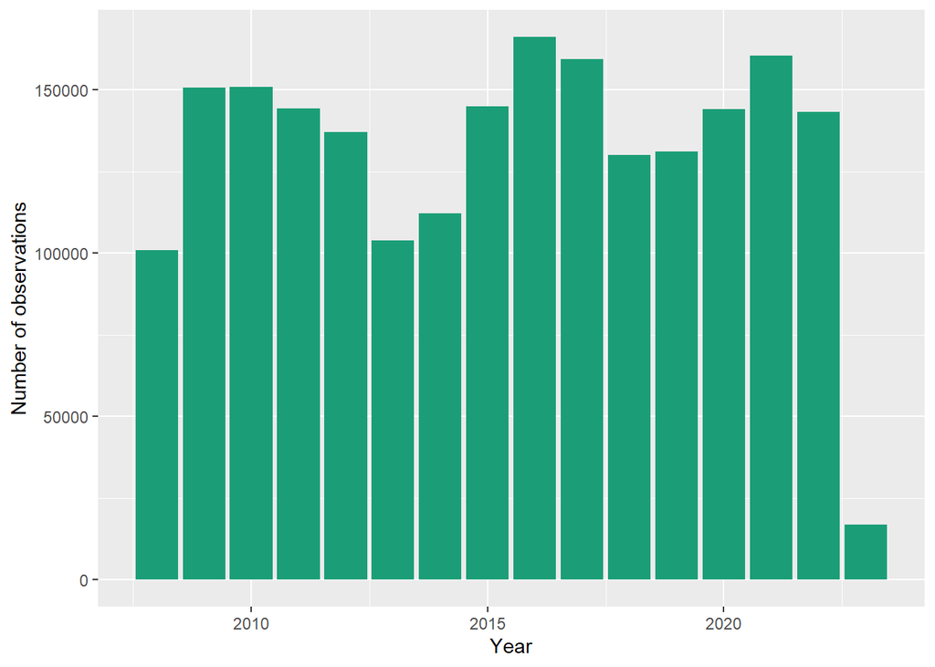

```r
# Number of observations per year
SABAP2WC %>%
  ggplot(aes(x = year(eventDate))) +
  geom_bar(fill = "#1B9E77") + labs(x = "Year",
       y = "Number of observations")
```

Number of observations has varied across the years. No specific trend. Number of observations range between 100 000 - 175 000 per year, excluding 2023. Note few observations for 2023, as only data up until February 2023 have been submitted to GBIF.

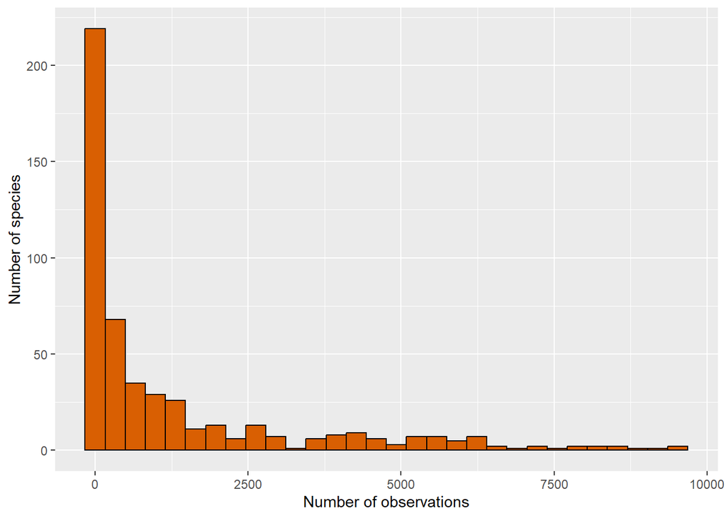

```r
# Number of observations per species
SABAP2WCGrp %>%
  group_by(species) %>%
  summarise(n_obs = n()) %>%
  ggplot(aes(x = n_obs)) +
  geom_histogram(fill = "#D95F02", color = "black") +
  labs(x = "Number of observations",
       y = "Number of species")
```

502 bird species recorded, of which 86 were recorded < 10 times (very rare), 81 were recorded between 10 and 100 times (rare), 94 were recorded between 100 and 1000 times (common), 162 were recorded between 1000 and 10000 times (very common), and 79 were recorded > 10000 times (extremely common).

```r
# Number of species falling into different commonness/observation categories
SABAP2WC %>%
  distinct(category, species) %>%
  group_by(category) %>%
  summarise(n())
```

```
## # A tibble: 5 × 2
##   category         `n()`
##   <fct>            <int>
## 1 Very rare           86
## 2 Rare                81
## 3 Common              94
## 4 Very common        162
## 5 Extremely common    79
```

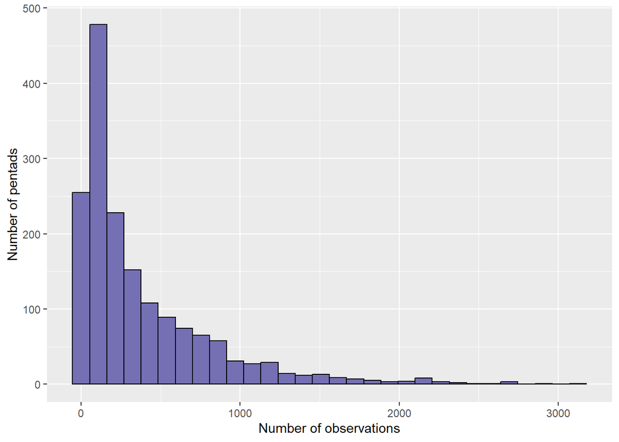

```r
# Number of observations per pentad
SABAP2WCGrp %>%
  group_by(pentad) %>%
  summarise(n_obs = n()) %>%
  ggplot(aes(x = n_obs)) +
  geom_histogram(fill = "#7570B3", color = "black") +
  labs(x = "Number of observations",
       y = "Number of pentads")
```

Number of observations vary across pentads, a few with > 2000 observations, but most have < 550 observations

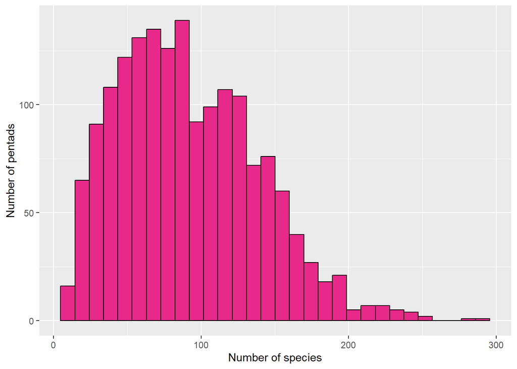

```r
# Number of species per pentad
SABAP2WCGrp %>%
  group_by(pentad) %>%
  summarise(nSpp = n_distinct(species)) %>%
  ggplot(aes(x = nSpp)) +
  geom_histogram(fill = "#E7298A", color = "black") +
  labs(x = "Number of species",
       y = "Number of pentads")
```

Number of species recorded varies per pentad. Most pentads have between 30 and 150 species recorded, few have > 200 species recorded.

# Compare bird data and survey data from SABAP2

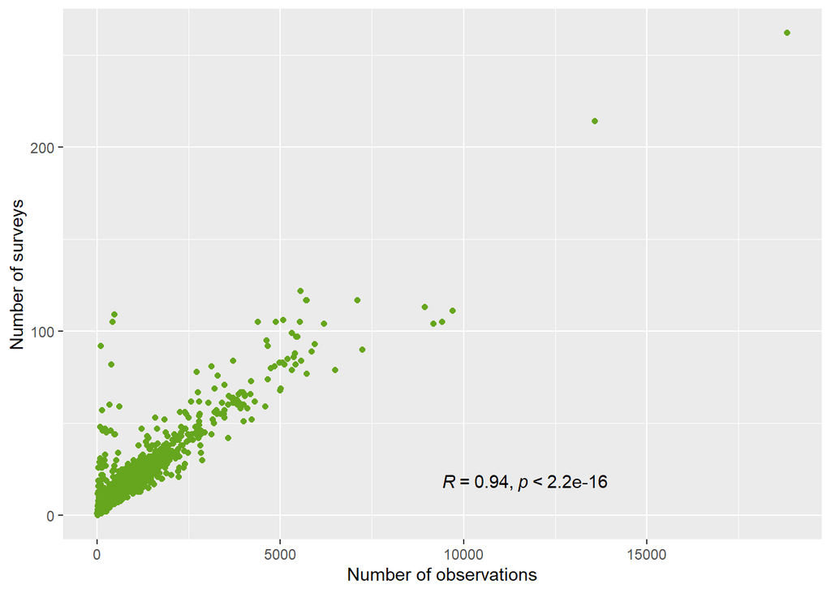

```r
# Plot number of surveys vs number of observations
SABAP2WC %>%
   group_by(year, pentad) %>%
    summarise(n = n()) %>%
  inner_join(WCSFprep,
            by = join_by(pentad, year)) %>%
  ggplot(aes(x = n, y = count)) +
  geom_point(color = "#66A61E") +
  ggpubr::stat_cor(mapping = aes(color = NULL),
           label.x.npc = "centre",
           label.y.npc = "bottom",
           method = "pearson") + labs(x = "Number of observations",
       y = "Number of surveys")
```

Strong correlation between number of surveys and number of observations

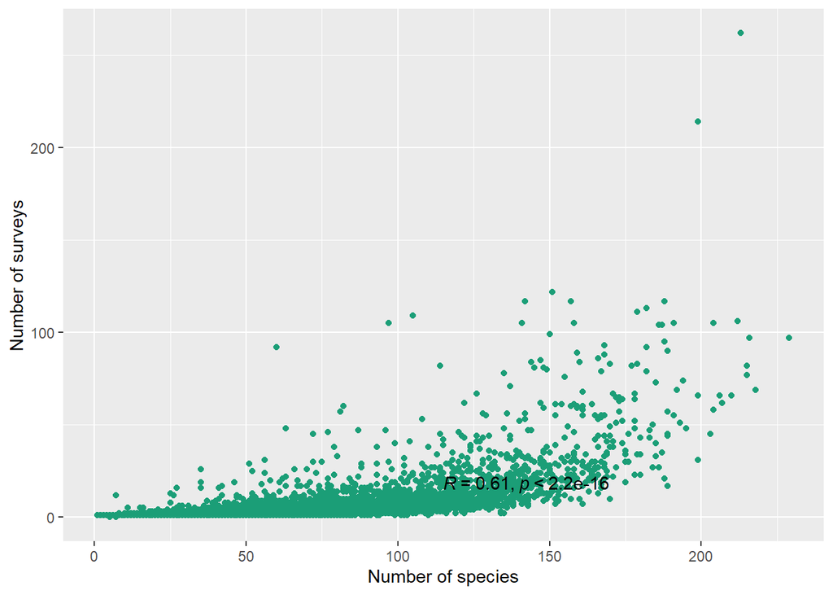

```r
# Plot number of surveys vs number of species
SABAP2WC %>%
  group_by(pentad, year) %>%
  summarise(nSpp = n_distinct(species)) %>%
  inner_join(WCSFprep,
            by = join_by(pentad, year)) %>%
  ggplot(aes(x = nSpp, y = count)) +
  geom_point(color = "#1B9E77") +
  ggpubr::stat_cor(mapping = aes(color = NULL),
           label.x.npc = "centre",
           label.y.npc = "bottom",
           method = "pearson") + labs(x = "Number of species",
       y = "Number of surveys")
```

Weaker correlation between number of surveys and number of species